# Taller 2 EST MAT

María Clara Avila

2025-03-21

# Punto 1

## Para las bases proporcionada para este taller, tuvimos que unir la variable Age de ambas bases, y como primer punto a resolver tenemos que determinar la media, mediana, desviación estandar y varianza de dichos datos

## Transformación de datos

```r
train_titanic %>%
  dplyr::select(-Survived) -> new_df_train

dataset <- merge(new_df_train, test_titanic, all = TRUE)

dataset %>%
  dplyr::select(Age, Sex) -> df
```

## Conteo de faltantes

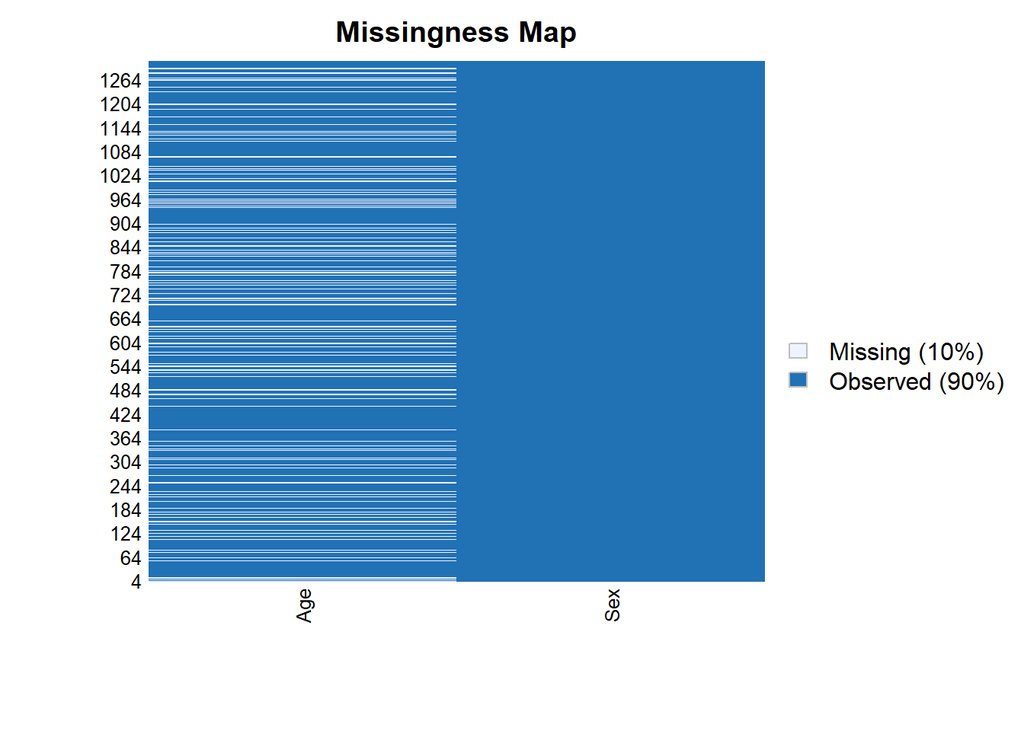

```r
missmap(df)
```

## Al hacer la imputación con de los NA con la media, nos dimos cuenta que no dio normal al hacer los tests de qqnorm y lillie, por lo cual tuvimos que imputar los datos faltantes con la mediana.

```r
df_nuevo <- median(df$Age, na.rm = TRUE)
df$Age[is.na(df$Age)] <- df_nuevo
write.csv(df, "df_nuevo1.csv", row.names = FALSE)
head(df)
```

```
##   Age    Sex
## 1  22   male
## 2  38 female
## 3  26 female
## 4  35 female
## 5  35   male
## 6  28   male
```

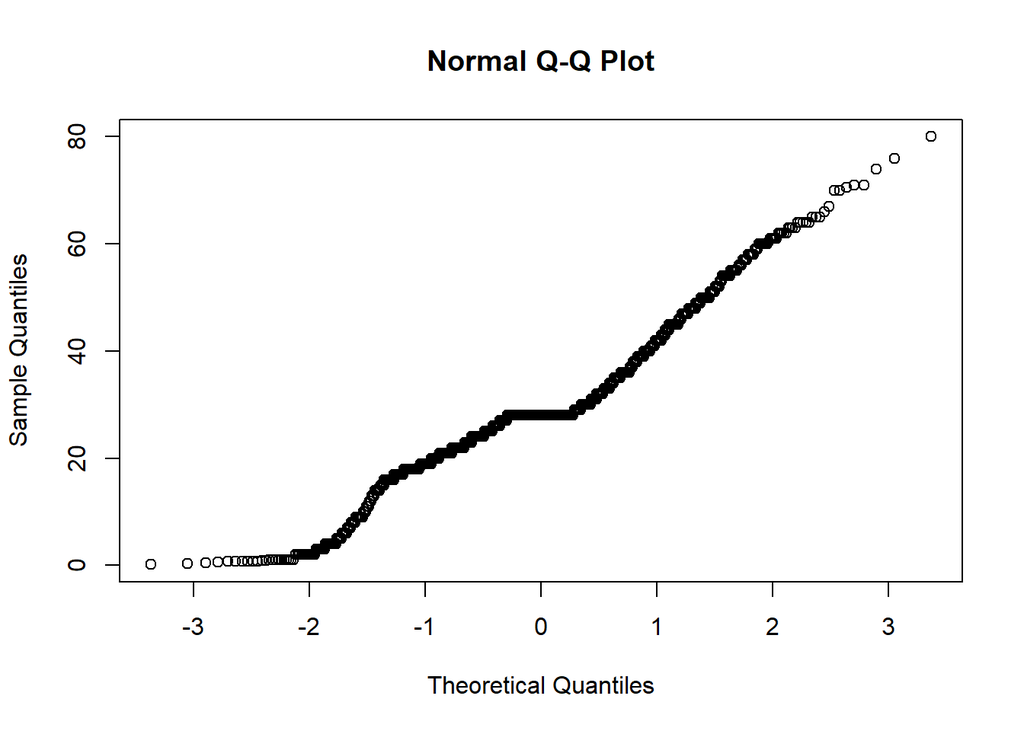

```r
qqnorm(df$Age)
```

```r
lillie.test((df$Age))
```

```
##
##  Lilliefors (Kolmogorov-Smirnov) normality test
##
## data:  (df$Age)
## D = 0.15675, p-value < 2.2e-16
```

## Calculamos la Media

```r
mean(df$Age)
```

```
## [1] 29.50319
```

## Mediana

```r
median(df$Age)
```

```
## [1] 28
```

## Desviación Estandar

```r
sd(df$Age)
```

```
## [1] 12.90524
```

## Varianza

```r
var(df$Age)
```

```
## [1] 166.5452
```

## También calculamos los cuartiles

```r
quantile(df$Age, probs = c(0.25, 0.50, 0.75), na.rm = TRUE)
```

```
## 25% 50% 75%
##  22  28  35
```

```r
summary(df$Age)
```

```
##    Min. 1st Qu.  Median    Mean 3rd Qu.    Max.
##    0.17   22.00   28.00   29.50   35.00   80.00
```

## El resumen de los cinco primeros números de la variable Age

```r
fivenum(df$Age)
```

```
## [1]  0.17 22.00 28.00 35.00 80.00
```

## Histograma Age

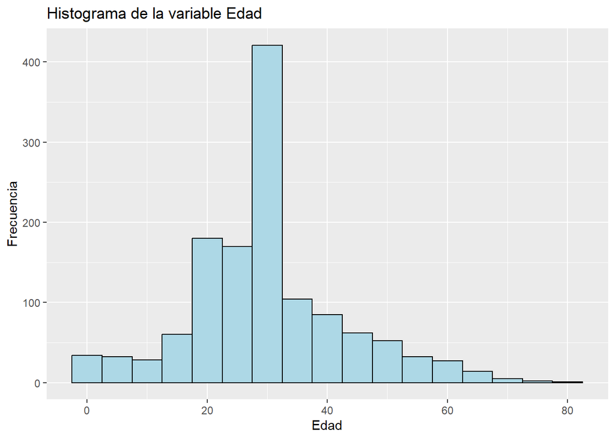

```r
ggplot(df, aes(x = Age)) +
  geom_histogram(binwidth = 5, fill = "lightblue", color = "black") +
  labs(title = "Histograma de la variable Edad", x = "Edad", y = "Frecuencia")
```

## Caja y Bigote Age

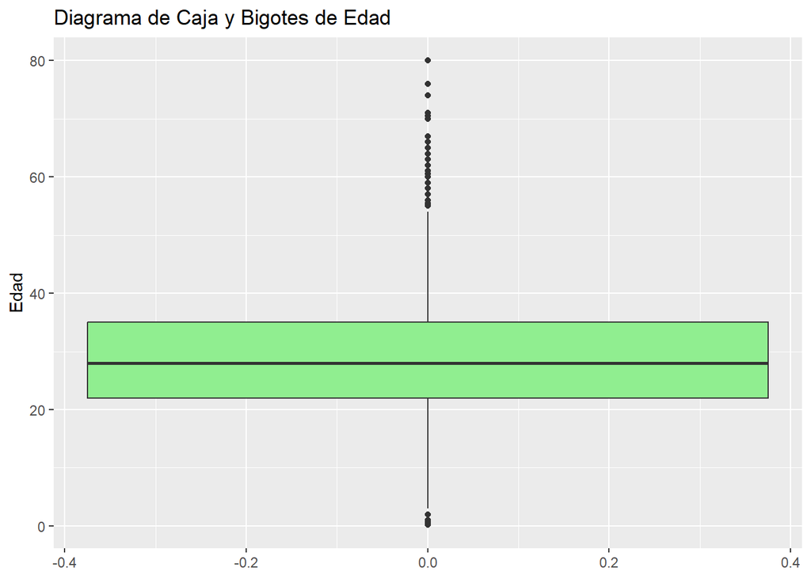

```r
ggplot(df, aes(y = Age)) +
  geom_boxplot(fill = "lightgreen") +
  labs(title = "Diagrama de Caja y Bigotes de Edad", y = "Edad")
```

# Punto 2

## Tomamos una configuración inicial

```r
set.seed(123)
library(tidyverse)
library(nortest)
library(rriskDistributions)
library(Amelia)
library(dplyr)

test_titanic <- read.csv("C:/Users/María Clara/Downloads/test_titanic.csv")
train_titanic <- read.csv("C:/Users/María Clara/Downloads/train_titanic.csv")
```

## Transformamos los datos

```r
train_titanic %>%
  dplyr::select(-Survived) -> new_df_train

dataset <- merge(new_df_train, test_titanic, all = TRUE)

dataset %>%
  dplyr::select(Age, Sex) -> df
```

## Contamos los dato faltantes

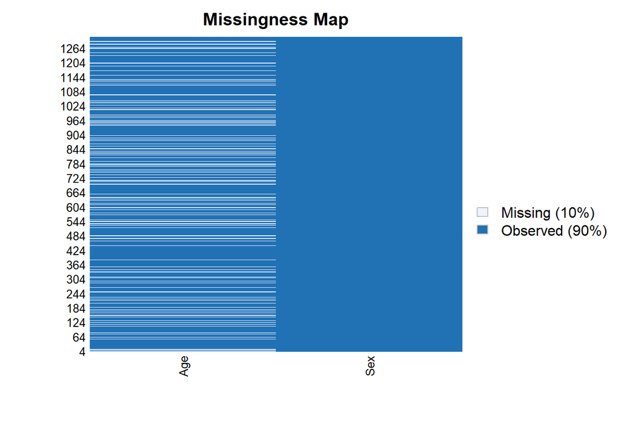

```r
missmap(df)
```

## Imputamos los datos faltantes con la mediana de Age

```r
df_nuevo <- median(df$Age, na.rm = TRUE)
df$Age[is.na(df$Age)] <- df_nuevo
write.csv(df, "df_nuevo.csv", row.names = FALSE)
```

## Hacemos un descriptivo

```r
head(df)
```

```
##   Age    Sex
## 1  22   male
## 2  38 female
## 3  26 female
## 4  35 female
## 5  35   male
## 6  28   male
```

```r
median(df$Age, na.rm = TRUE)
```

```
## [1] 28
```

```r
mean(df$Age)
```

```
## [1] 29.50319
```

```r
median(df$Age)
```

```
## [1] 28
```

## Comprobamos normalidad

```r
lillie.test(df$Age)
```

```
##
##  Lilliefors (Kolmogorov-Smirnov) normality test
##
## data:  df$Age
## D = 0.15675, p-value < 2.2e-16
```

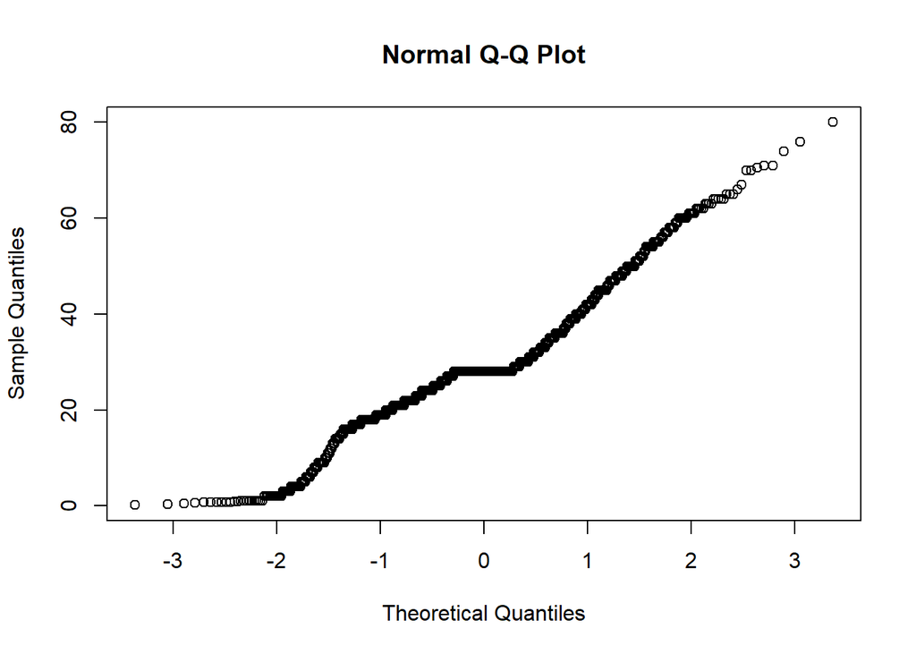

```r
qqnorm(df$Age)
```

```r
var(df$Age)
```

```
## [1] 166.5452
```

## Primero, hacer un bucle para las 1000 muestras de la variable edad mayores a 30

## Filtrar personas mayores de 30 años

```r
df_filtered <- df %>% filter(Age > 30)
```

## Parámetros para el bucle

```r
M <- 1000  # Número de muestras
n_values <- c(50, 100, 200)  # Valores de n que vamos a probar
```

## Bucle para variar n

```
##
##  Lilliefors (Kolmogorov-Smirnov) normality test
##
## data:  z
## D = 0.029481, p-value = 0.03983
```

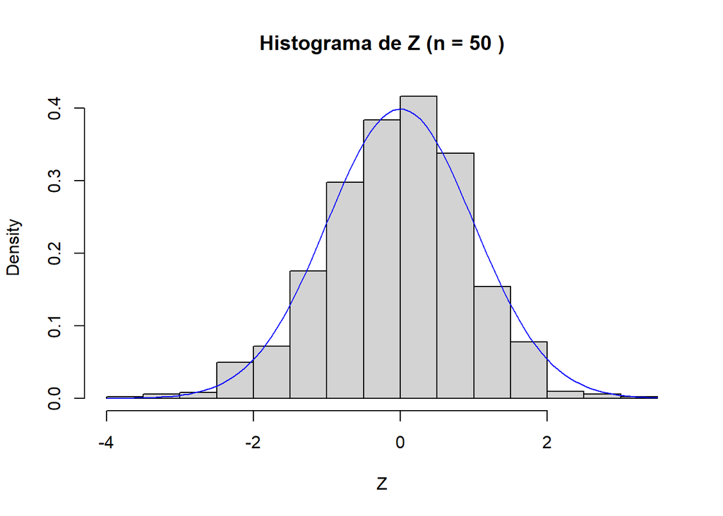

```
##
##  Lilliefors (Kolmogorov-Smirnov) normality test
##
## data:  z
## D = 0.016584, p-value = 0.7251
```

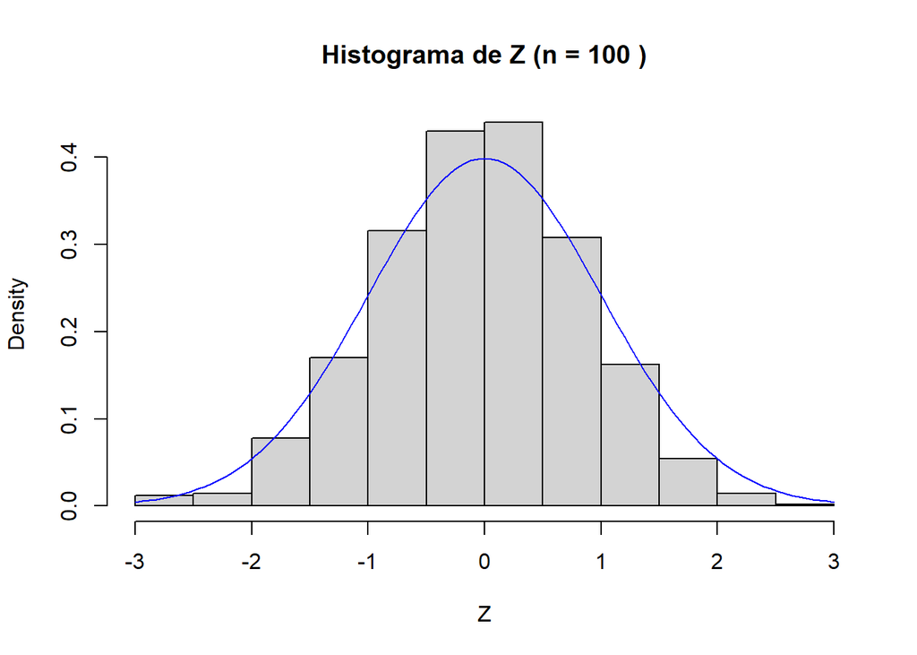

```
##
##  Lilliefors (Kolmogorov-Smirnov) normality test
##
## data:  z
## D = 0.025514, p-value = 0.1182
```

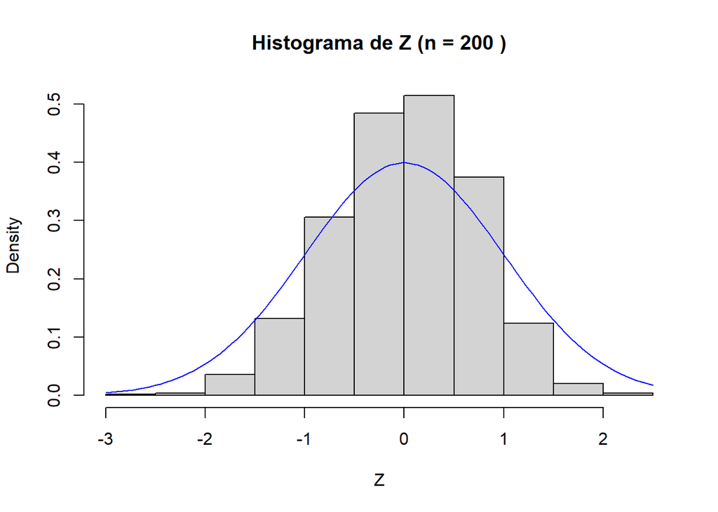

```r
for (n in n_values) {
  # Inicializar el vector z para almacenar los estadísticos
  z <- rep(NA, M)

  # Bucle para generar muestras y calcular estadísticos
  for (i in 1:M) {
    sample_ages <- sample(df_filtered$Age, n)
    sample_mean <- mean(sample_ages)
    sample_sd <- sd(sample_ages)
    z[i] <- (sample_mean - mean(df_filtered$Age)) / (sample_sd / sqrt(n))
  }

  # Prueba de normalidad
  print(lillie.test(z))

  # Dibujar histograma y distribución normal estándar
  hist(z, freq = FALSE, main = paste("Histograma de Z (n =", n, ")"), xlab = "Z")
  curve(dnorm(x, mean = 0, sd = 1), add = TRUE, col = "blue")

}
```

# Conclusiones

## Como podemos ver si variamos el n con los valores de 50 100 y 200 notamos que con 50 no cumplen normalidad mientras que con 100 y 200 si

# Punto 4

## Para este punto se dividieron en 4 incisos, en el primero se hace un bucle para generar 1000 muestras aleatorias de tamaño n = 50 de la variable “edad de mujeres” y 1000 muestras de tamaño n = 60 de la variable “edad de hombres”

```r
library(ggplot2)
library(knitr)
library(dplyr)
library(gt)
library(nortest)
```

# **Análisis de Diferencia de Proporciones**

## Este análisis busca estudiar la diferencia de proporciones entre mujeres y hombres mayores de 30 años en el Titanic, mediante simulaciones y pruebas estadísticas.

# **Carga y Combinación de Datos**

## Se carga la información de los pasajeros desde los archivos de entrenamiento y prueba, combinando los datos y seleccionando solo las variables de interés: edad y género.

```r
# Cargar el paquete dplyr
library(dplyr)

# Cargar los datasets desde archivos CSV
test_titanic <- read.csv("C:/Users/María Clara/Downloads/test_titanic.csv")
train_titanic <- read.csv("C:/Users/María Clara/Downloads/train_titanic.csv")

# Eliminar la columna 'Survived' del dataframe train_titanic
new_df_train <- train_titanic %>% dplyr::select(-Survived)

# Combinar los dataframes usando merge (full join)
dataset <- merge(new_df_train, test_titanic, all = TRUE)

# Seleccionar solo las columnas Age y Sex
df <- dataset %>% dplyr::select(Age, Sex)

# Verificar el resultado
head(df)
```

```
##   Age    Sex
## 1  22   male
## 2  38 female
## 3  26 female
## 4  35 female
## 5  35   male
## 6  NA   male
```

## Unir los datos manteniendo solo Age y Sex

```r
datos_titanic <- train_titanic %>% dplyr::select(Age, Sex) %>%
  bind_rows(test_titanic %>% dplyr::select(Age, Sex))
```

# **Distribución de Edades Antes de la Imputación**

## Se grafica la distribución de edades antes de imputar valores faltantes para entender la estructura de los datos.

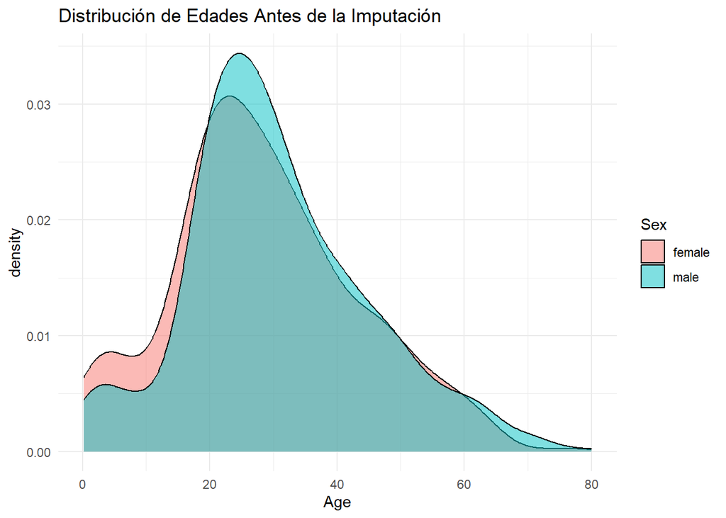

```r
ggplot(datos_titanic, aes(x = Age, fill = Sex)) +
  geom_density(alpha = 0.5) +
  theme_minimal() +
  ggtitle("Distribución de Edades Antes de la Imputación")
```

# **Prueba de Normalidad de Lilliefors**

## Antes de imputar valores faltantes en la edad, verificamos si sigue una distribución normal mediante la prueba de Lilliefors.

```r
prueba_lillie <- lillie.test(na.omit(datos_titanic$Age))
p_valor <- prueba_lillie$p.value
es_normal <- p_valor > 0.05
```

# **Imputación de Datos Faltantes**

## Dependiendo del resultado de la prueba de normalidad, se imputan los valores faltantes de la edad con la media o la mediana.

```r
if (es_normal) {
  datos_titanic$Age[is.na(datos_titanic$Age)] <- mean(datos_titanic$Age, na.rm = TRUE)
} else {
  datos_titanic$Age[is.na(datos_titanic$Age)] <- median(datos_titanic$Age, na.rm = TRUE)
}
```

# **Distribución de Edades Después de la Imputación**

## Después de la imputación, se grafica nuevamente la distribución de edades para comparar con la original.

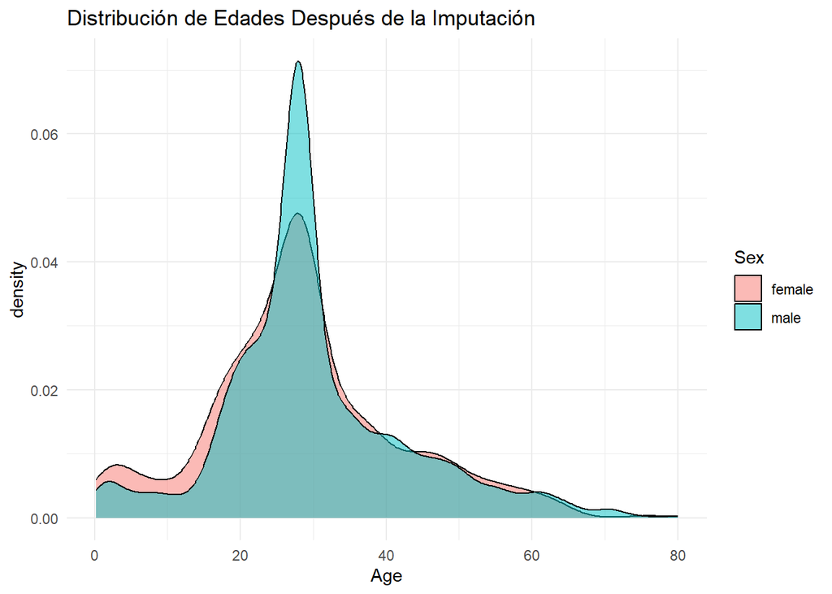

```r
ggplot(datos_titanic, aes(x = Age, fill = Sex)) +
  geom_density(alpha = 0.5) +
  theme_minimal() +
  ggtitle("Distribución de Edades Después de la Imputación")
```

# **Generación de Muestras Aleatorias**

## Se extraen 1000 muestras aleatorias de tamaño n=50 para mujeres y n=60 para hombres, calculando la proporción de individuos mayores de 30 años en cada muestra.

```r
set.seed(123)
mujeres_muestras <- replicate(1000, mean(sample(datos_titanic$Age[datos_titanic$Sex == "female"], 50, replace = TRUE) > 30))
hombres_muestras <- replicate(1000, mean(sample(datos_titanic$Age[datos_titanic$Sex == "male"], 60, replace = TRUE) > 30))

dif_proporciones <- mujeres_muestras - hombres_muestras
```

# **Histogramas de la Diferencia de Proporciones**

## El histograma muestra la distribución de la diferencia entre proporciones de mujeres y hombres mayores de 30 años en las muestras.

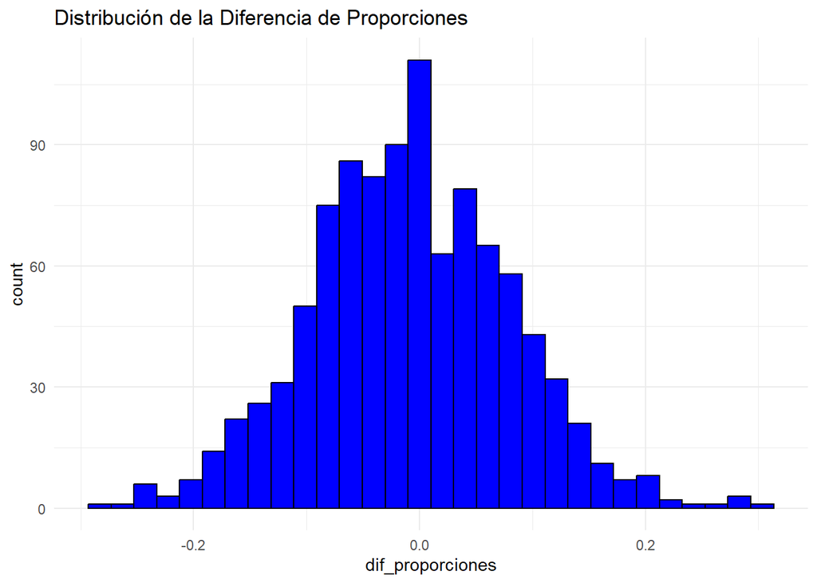

```r
ggplot(data.frame(dif_proporciones), aes(x = dif_proporciones)) +
  geom_histogram(fill = "blue", color = "black", bins = 30) +
  theme_minimal() +
  ggtitle("Distribución de la Diferencia de Proporciones")
```

# **Boxplot de la Diferencia de Proporciones**

## Se incluye un boxplot para visualizar la variabilidad y presencia de valores atípicos en la diferencia de proporciones.

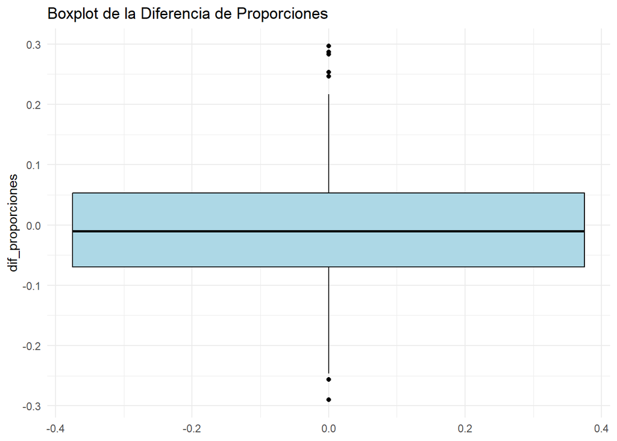

```r
ggplot(data.frame(dif_proporciones), aes(y = dif_proporciones)) +
  geom_boxplot(fill = "lightblue", color = "black") +
  theme_minimal() +
  ggtitle("Boxplot de la Diferencia de Proporciones")
```

# **Gráfico Q-Q para la Diferencia de Proporciones**

## El gráfico Q-Q permite comparar la distribución muestral con una distribución normal teórica, evaluando el cumplimiento del teorema de diferencia de proporciones.

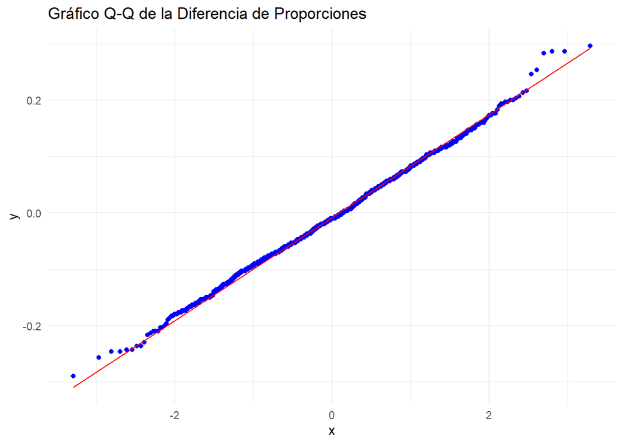

```r
ggplot(data.frame(dif_proporciones), aes(sample = dif_proporciones)) +
  stat_qq(color = "blue") + stat_qq_line(color = "red") +
  theme_minimal() +
  ggtitle("Gráfico Q-Q de la Diferencia de Proporciones")
```

# **Cálculo de Probabilidades Empíricas y Teóricas**

## Se calcula la probabilidad empírica de que la diferencia de proporciones muestrales sea mayor a cero y se compara con la diferencia de proporciones poblacional.

```r
probabilidad_empirica <- mean(dif_proporciones > 0)

prop_mujeres_30_total <- mean(datos_titanic$Age[datos_titanic$Sex == "female"] > 30, na.rm = TRUE)
prop_hombres_30_total <- mean(datos_titanic$Age[datos_titanic$Sex == "male"] > 30, na.rm = TRUE)

dif_proporciones_teorica <- prop_mujeres_30_total - prop_hombres_30_total

resultados <- data.frame(
  "Probabilidad Empírica" = probabilidad_empirica,
  "Proporción Mujeres > 30 (Total)" = prop_mujeres_30_total,
  "Proporción Hombres > 30 (Total)" = prop_hombres_30_total,
  "Diferencia de Proporciones Teórica" = dif_proporciones_teorica
)

knitr::kable(resultados, caption = "Resultados de la Diferencia de Proporciones y Probabilidad Empírica")
```

Resultados de la Diferencia de Proporciones y Probabilidad Empírica

| Probabilidad.Empírica | Proporción.Mujeres…30..Total. | Proporción.Hombres…30..Total. | Diferencia.de.Proporciones.Teórica |
| --- | --- | --- | --- |
| 0.44 | 0.3283262 | 0.3368921 | -0.0085659 |

## Este análisis proporciona una comparación clara entre las proporciones observadas y teóricas, permitiendo evaluar la diferencia de proporciones mediante métodos gráficos y probabilísticos.